# Marathon Man

Notes for Historians at the Movies

Eric Rauchway

*Marathon Man* was [a Paramount Pictures movie of 1976,](https://www.imdb.com/title/tt0074860/) produced by Robert Evans and Sidney Beckerman and directed by John Schlesinger from a script by William Goldman based on his 1974 novel of the same name. It comes from a time in movie history familiar to Historians at the Movies; it starred Dustin Hoffman, who was in #HATM-covered *All the President’s Men* the same year, and Roy Scheider, who was in #HATM-covered *Jaws* the previous year. It garnered Laurence Olivier [an Oscar nomination for Actor in a Supporting Role](https://www.oscars.org/oscars/ceremonies/1977); that award went to Jason Robards for *All the President’s Men.* As it happens, *All the President’s Men* also pulled in an Oscar for adapted screenplay for *Marathon Man* author William Goldman—his second; he had won a best original screenplay Oscar for *Butch Cassidy and the Sundance Kid* (which might someday qualify for #HATM treatment). And I bet a lot of folks will be familiar with Goldman’s other great success, with the 1973 book and the screenplay for the 1987 movie, *The Princess Bride*; moreover, his World War II epic, *A Bridge Too Far* (1977), might also someday belong on the #HATM list. He was a great talent, he worked hard, and [he had range.](https://bulletproofscreenwriting.tv/william-goldman-screenplays-download/) And was the first to tell people he was also very lucky; he got into screenwriting, he said, based on a misconception—Cliff Robertson thought an experimental novel Goldman had written was a superb screen treatment.

[figure not shown]

If you want to put the movie in context, the poster for *Marathon Man* calls it a thriller, which it obviously is, and you can think of it as a movie that belongs in conversation with other 1970s thrillers that pit an ambitious Hollywood leading man against a shadowy government conspiracy. So you might think of Robert Redford in *Three Days of the Condor* (1975) or Warren Beatty in *The Parallax View* (1974). I bet Hoffman was thinking of those, anyway. You might also think of it as connected to other gritty New York City movies of the same era; it comes from the same year as *Taxi Driver* and just after *The Taking of Pelham One Two Three* (1974)—the latter of which is, for my money, the best New York City movie of all time. *Marathon Man* came out the year after [“Ford to City: Drop Dead”](https://www.history.com/speeches/ford-to-city-drop-dead) and the year before the blackout and the “Son of Sam” murders. It’s to some degree set in a legendarily unpleasant New York City—this movie is very much influenced by the [myth of Kitty Genovese, which was taken as truth by many New Yorkers at the time,](https://www.latimes.com/opinion/story/2020-09-10/urban-legend-kitty-genovese-38-people) that nobody responds to a call for help. (Although *Marathon Man* does have a twist on that, when the neighborhood delinquents do respond to Hoffman’s actual telephone call for help, but let’s not get ahead of ourselves.) But it has to be New York City, because of the need for history to be present, in the form of communities of German and Jewish émigrés from Europe.

For me, though, I think it’s most useful to think of this story as a very personal story for Goldman, and one that’s suffused with trauma, both individual and social. So yes, as Charlie Pierce already led the way in pointing out, a lot of you may want a warning that there’s [A Scene](https://twitter.com/CharlesPPierce/status/1574789348251373574) in this movie. And indeed there’s a lot of content people might want to be warned about: lethal violence, suicide, torture, plus a certain amount of thoughtless racism and sexism.

But I think The Scene stands in for much bigger traumas that are central to the movie, and churning away underneath it. Goldman was [a Jewish writer whose father committed suicide,](https://forward.com/schmooze/414370/princess-bride-writer-william-goldman-dead-but-immortal-forever/) so it’s not a big stretch to suppose that when he writes about a Jewish writer whose father committed suicide, there are some personal stakes. The movie is also drenched in the generational trauma of Jewish Americans of that era, and indeed since: the Holocaust. Goldman, in his memoir, says almost nothing about writing *Marathon Man*; the chapter devoted to it consists almost entirely anecdotes about Olivier. I suspect Goldman preferred not to talk about why the story mattered to him.

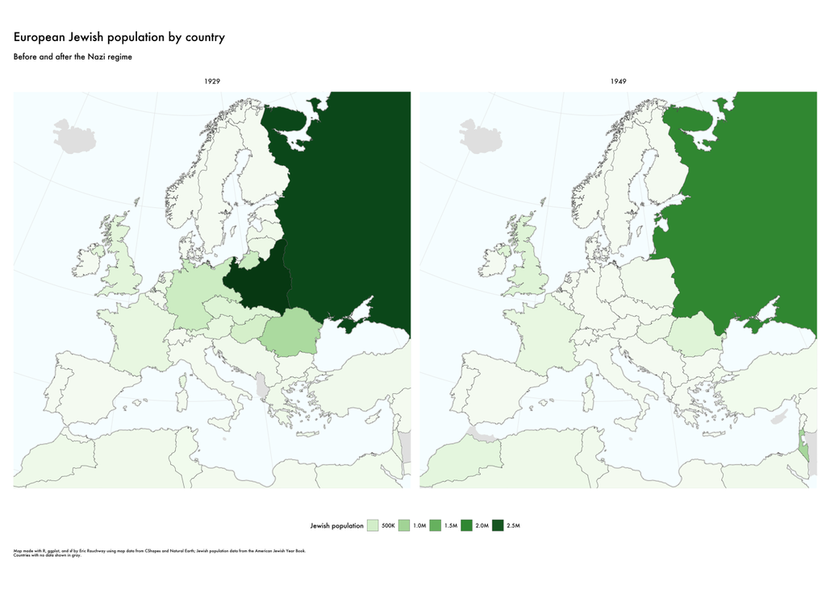

All that trauma, both individual and social, is invoked in this film, and also, importantly I think, unresolved.

Goldman was fascinated and also frustrated by history; that was how he got into writing about Butch Cassidy. He was just taken with the story and also how difficult it was to really know anything about it. Uncertainty was one of Goldmanʻs major themes. You may know his maxim about Hollywood: “nobody knows anything.” But it’s often misquoted, sort of; people put the emphasis on “anything,” but the emphasis belongs on “knows”: nobody is *certain* of anything; “not one person in the entire motion picture field *knows* for a certainty what’s going to work.” He also thought that nobody really knows any *one,* either. And that’s what Goldman understood about history, too. We don’t *know* much; we can’t know much. But, as he said about writing *Butch Cassidy*: “I did all the research I could bear,” and then started writing. The script took him four weeks. But he had researched for eight years. You have to do as much research as you can endure—and then “once you start writing, go like hell” but, he added, in a phrase that is also evocative of *Marathon Man,* “don’t fire till you’re ready.” Writing history is an act first of endurance, and then violence. But also, it’s futile; you can do the best job possible with the narrative and still not make it come out right: “endings, frankly, are a bitch.”

Goldman, *Adventures in the Screen Trade,* 39, 118, 123–124, 286.

And even if you do get it right, it might not make you feel good. It won’t relieve your suffering; it won’t expunge your trauma.

The central metaphor of the movie is endurance; as Goldman says, how much can you bear. That’s what a marathon is about—endurance. The movie opens with footage of Ethiopian runner Abebe Bikila at the 1964 Olympics, winning the marathon [for the second time; in 1960, he had won running barefoot.](https://www.youtube.com/watch?v=w_Nygi01VqI) He exemplified endurance, and the recurring image of him in the movie invokes that theme.

Hoffman’s character, Babe Levy (named Thomas Babington Levy, after the historian Thomas Babington Macaulay), sets out to master history, to vindicate his father, to write the narrative that will make everything right. But, as his (thoroughly obnoxious) mentor warns him, as his brother warns him, he can’t do that. While history can destroy you—look what it does to the poor old fellow in the diamond district—you can’t defeat it. You can only learn to endure the pain that the past inflicts on you.

One last note before watching: Babe is the protagonist (and of course his nickname has multiple meanings) but itʻs his brother—who, it turns out, nobody really knows (you might catch all the ways this is true if youʻre paying especially close attention) and who is misunderstood even by the people closest to him, who inadvertently and unknowingly sets the major conflict rolling.